# HW2_Statistical Machine Learning

Moran Guo

2024-09-22

## Question 1 (5.4-1)

Simplifying the equation using $\mathrm{Var}(aX) = a^2 \mathrm{Var}(X)$ and $\mathrm{Cov}(cX, dY) = cd \cdot \mathrm{Cov}(X, Y)$, we have
$$\mathrm{Var}\Big(\alpha X + (1-\alpha)Y\Big) =
\alpha^2 \mathrm{Var}(X) + (1 - \alpha)^2\mathrm{Var}(Y) +
2\alpha(1-\alpha)\cdot \mathrm{Cov}(X,Y).$$

We find the first derivative of the above equation with respect to $\alpha$, and let it equal to $0$ to find the extremum:

$$2\alpha\mathrm{Var}(X) +
(-2)(1-\alpha)\mathrm{Var}(Y) + 2(1-2\alpha)\mathrm{Cov}(X, Y) = 0
\Rightarrow \alpha = \frac{\mathrm{Var}(Y) -
\mathrm{Cov}(X,Y)}{\mathrm{Var}(X) + \mathrm{Var}(Y) -
2\mathrm{Cov}(X,Y)}.$$

To verify this extremum is a minimum, we differentiate it again with respect to $\alpha$, and we have
$$2\mathrm{Var}(X) + 2\mathrm{Var}(Y) -
4\mathrm{Cov}(X,Y) = \mathrm{Var}(X) + \mathrm{Var}(Y) -
2\mathrm{Cov}(X,Y) = \mathrm{Var}(|X-Y|) \geq 0,$$

Therefore, we confirm that this $\alpha$ minimizes $\mathrm{Var}\Big(\alpha X + (1-\alpha)Y\Big)$.

## Question 2 (5.4-3)

### (a)

For the entire dataset, $k$-fold cross validation is implemented by dividing it into $k$ parts of equal size. The model will be fitted $k$ times, with one of the $k$ subsets serving as the test set and the remaining $k-1$ subsets forming training set. The average error across $k$ trials is computed at the end.

### (b)

#### (i)

Advantage of $k$-fold CV compared to validation set:

1. More efficient use of the dataset, since the data is splitted into $k$ folds and the model is fitted $k$ times with different combination of folds for training and validation. However, for the validation set approach, the data is only splitted into one validation set and one training set, meaning the model is only trained on part of the data, which is less efficient.
2. Less variance in model error. $k$-fold CV often results in less variance in performance estimates, since the model was fitted $k$ times and the results were averaged across multiple validation sets, thus the output error is more robust and less dependent on a single split. Whereas validation set approach only fit the model once, and if the validation set split happens to contain more extreme data points which are harder to fit, then the performance of the model may be affected by those data points.

Disadvantage of $k$-fold CV compared to validation set:

1. Higher computational cost and more complex to implement. It is trivial, since for $k$-fold CV, the model need to be fitted and trained $k$ times, which can be particular challenging for large datasets and/or complex models. But validation set approach only need to train the model once, which requires less computational costs.

#### (ii)

Advantage of $k$-fold CV compared to LOOCV:

1. Lower computational cost compared to LOOCV. Since LOOCV is essentially $n$-fold CV, when $n$ is large (e.g., $n > 10$), the model need to be fitted and trained $n$ times, as compared to $k$-fold CV, with $k$ normally equals to $5$ or $10$. Therefore LOOCV is more computationally intensive compared to $k$-fold CV, especially when $n$ is large.
2. More control over bias-variance tradeoff. $k$-fold CV allows us to control the value of $k$ to account for an adequate level of variance and bias. However, LOOCV always uses $n-1$ data points for training, which often time result in low bias but high variance, especially for small datasets. This is due to the fact that for LOOCV, the overlap between training sets is large, and these highly correlated quantities often have high variances compared to those quantities that are not as much correlated, which occurs in $k$-fold CV.

Disadvantage of $k$-fold CV compared to LOOCV:

1. Slightly higher bias compared to LOOCV. Since $k$-fold CV utilizes smaller training set for every fold, it will results in slightly higher bias than the LOOCV, which uses almost the entire dataset for training.
2. Not optimal for small dataset compared to LOOCV. When the total number of observation $n$ is small, LOOCV could perform better than $k$-fold CV because it utilizes nearly all available data for training, where as $k$-fold CV only trains the model using $(k-1)/k$ of the data, which could limit the model performance when $n$ is small.

## Question 3 (5.4-5)

### (a)

```r
# Install required packages
library(ISLR)

set.seed(644)

default_glm_fit <- glm(default ~ income + balance, data = Default, family = "binomial")

summary(default_glm_fit)
```

```
##
## Call:
## glm(formula = default ~ income + balance, family = "binomial",
##     data = Default)
##
## Coefficients:
##               Estimate Std. Error z value Pr(>|z|)
## (Intercept) -1.154e+01  4.348e-01 -26.545  < 2e-16 ***
## income       2.081e-05  4.985e-06   4.174 2.99e-05 ***
## balance      5.647e-03  2.274e-04  24.836  < 2e-16 ***
## ---
## Signif. codes:  0 '***' 0.001 '**' 0.01 '*' 0.05 '.' 0.1 ' ' 1
##
## (Dispersion parameter for binomial family taken to be 1)
##
##     Null deviance: 2920.6  on 9999  degrees of freedom
## Residual deviance: 1579.0  on 9997  degrees of freedom
## AIC: 1585
##
## Number of Fisher Scoring iterations: 8
```

### (b)

```r
set.seed(644)

# Train-test split
train_set <- sample(nrow(Default), nrow(Default) * 0.80)

# Model fit
default_glm_fit_vs <- glm(default ~ income + balance, data = Default, family = "binomial", subset = train_set)

# Predict on the test set
default_prob_vs <- predict(default_glm_fit_vs, Default[-train_set, ], type = "response")

# Assign to the predicted status
default_pred_vs <- ifelse(default_prob_vs > 0.5, "Yes", "No")

table(default_pred_vs, Default[-train_set, ]$default)
```

```
##
## default_pred_vs   No  Yes
##             No  1920   51
##             Yes    6   23
```

```r
# Validation set error
mean(Default[-train_set, ]$default != default_pred_vs)
```

```
## [1] 0.0285
```

### (c)

```r
for (i in 15:17) {
  set.seed(i)
  train_set <- sample(nrow(Default), nrow(Default) * 0.80)

  default_glm_fit_vs <- glm(default ~ income + balance, data = Default, family = "binomial", subset = train_set)

  default_prob_vs <- predict(default_glm_fit_vs, Default[-train_set, ], type = "response")

  default_pred_vs <- ifelse(default_prob_vs > 0.5, "Yes", "No")

  #table(default_pred_vs, Default[-train_set, ]$default)

  print(mean(Default[-train_set, ]$default != default_pred_vs))

}
```

```
## [1] 0.0275
## [1] 0.0275
## [1] 0.028
```

From the output test errors, we may safely assume that our method may not have much variance.

### (d)

```r
set.seed(644)

# Train-test split
train_set <- sample(nrow(Default), nrow(Default) * 0.80)

# Model fit with `student` as dummy
default_glm_fit_vs <- glm(default ~ income + balance + student, data = Default, family = "binomial", subset = train_set)

# Predict on the test set
default_prob_vs <- predict(default_glm_fit_vs, Default[-train_set, ], type = "response")

# Assign to the predicted status
default_pred_vs <- ifelse(default_prob_vs > 0.5, "Yes", "No")

table(default_pred_vs, Default[-train_set, ]$default)
```

```
##
## default_pred_vs   No  Yes
##             No  1919   51
##             Yes    7   23
```

```r
# Validation set error
mean(Default[-train_set, ]$default != default_pred_vs)
```

```
## [1] 0.029
```

From the result, we can see that `student` as a dummy variable does not changes the test error too much.

## Question 4 (5.4-6)

### (a)

```r
library(ISLR)

set.seed(644)

default_glm_fit <- glm(default ~ income + balance, data = Default, family = "binomial")

summary(default_glm_fit)
```

```
##
## Call:
## glm(formula = default ~ income + balance, family = "binomial",
##     data = Default)
##
## Coefficients:
##               Estimate Std. Error z value Pr(>|z|)
## (Intercept) -1.154e+01  4.348e-01 -26.545  < 2e-16 ***
## income       2.081e-05  4.985e-06   4.174 2.99e-05 ***
## balance      5.647e-03  2.274e-04  24.836  < 2e-16 ***
## ---
## Signif. codes:  0 '***' 0.001 '**' 0.01 '*' 0.05 '.' 0.1 ' ' 1
##
## (Dispersion parameter for binomial family taken to be 1)
##
##     Null deviance: 2920.6  on 9999  degrees of freedom
## Residual deviance: 1579.0  on 9997  degrees of freedom
## AIC: 1585
##
## Number of Fisher Scoring iterations: 8
```

We conclude from the table that the standard errors correspond to `income` and `balance` equal to $4.985e-06$ and $2.274e-04$ respectively.

### (b)

```r
boot_fn = function(data = Default, index) {
  return(coef(glm(default ~ income + balance,
                  data,
                  family = binomial,
                  subset = index))[c("income", "balance")])
}
```

### (c)

```r
library(boot)

boot(Default, boot_fn, R = 100)
```

```
##
## ORDINARY NONPARAMETRIC BOOTSTRAP
##
##
## Call:
## boot(data = Default, statistic = boot_fn, R = 100)
##
##
## Bootstrap Statistics :
##         original       bias     std. error
## t1* 2.080898e-05 6.167101e-07 5.129934e-06
## t2* 5.647103e-03 2.318021e-05 2.206912e-04
```

### (d)

The standard errors from the bootstrapping and from the previous `glm()` call are very similar.

## Question 5 (6.8-1)

### (a)

Best subset model with $k$ predictors has the smallest training error.

### (b)

We don’t know any information regarding the test set, so it could be any of these three model.

### (c)

#### i.

True. This is the definition of forward stepwise selection.

#### ii.

True. This is the definition of backward stepwise selection.

#### iii.

False. The predictors of backward / forward stepwise selection at a particular step depends on the previous stage of the selection process. It is not dependent on the other selection strategy.

#### iv.

False. Reason is the same as iii. — The predictors of backward / forward stepwise selection at a particular step depends on the previous stage of the selection process. It is not dependent on the other selection strategy. So there’s no guarantee that one strategy (forward / backward selection) has a relationship with the other.

#### v.

False. The selection of variables using the best subset model **solely** depends on the subset that minimizes RSS on the training set. So it is not necessarily nested for $k$ and $k+1$ predictors.

## Question 6 (6.8-8)

### (a)

```r
set.seed(567)

x <- rnorm(100)
error <- rnorm(100)
```

### (b)

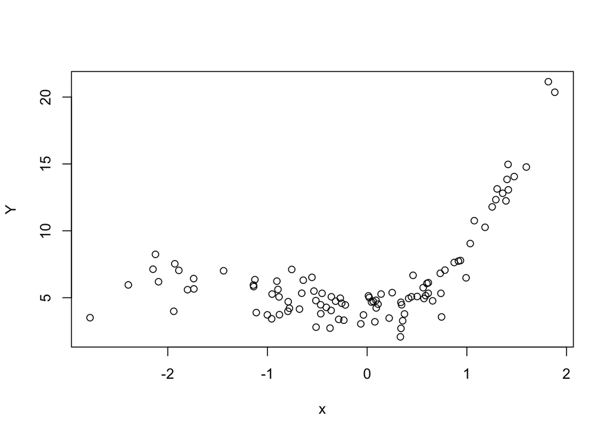

```r
Y <- 4 + (0.5) * x + 3 * x^2 + 1 * x^3 + error

plot(x, Y)
```

### (c)

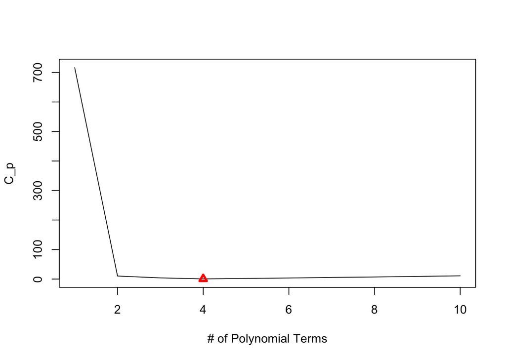

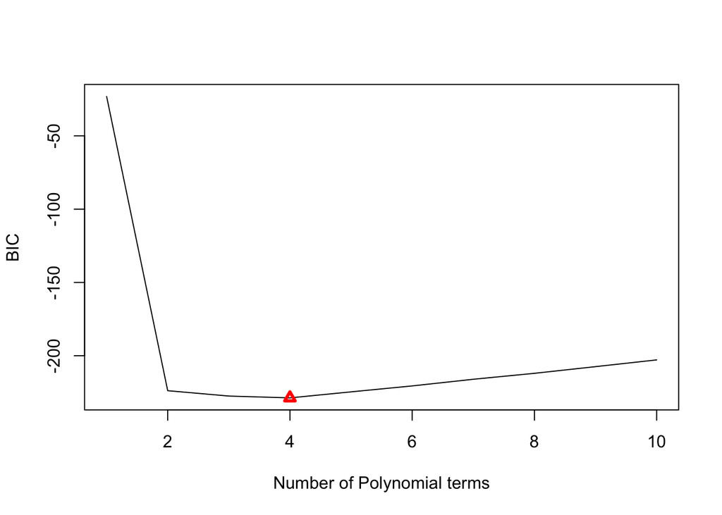

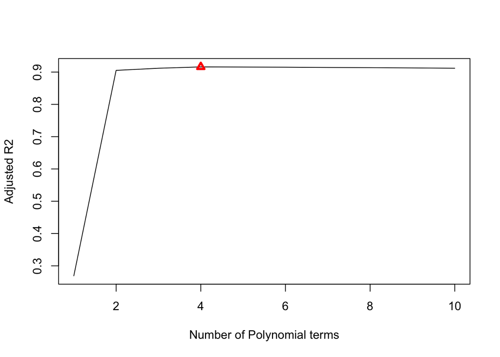

[output not shown]

From the result, we can see that adjusted $R^2$, $BIC$, and $C_p$ all choose the 4-variable model. Therefore, the best model is the 4 variables listed above.

### (d)

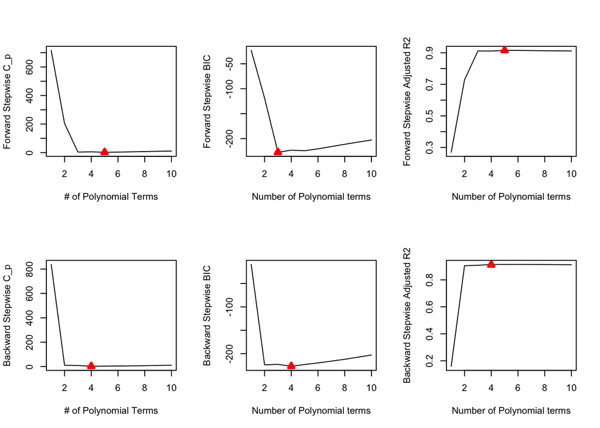

```r
reg_forward <- regsubsets(Y ~ ., data = data.frame(Y, x_vec), nvmax = 10, method = "forward")
forward_summary <- summary(reg_forward)

reg_backward <- regsubsets(Y ~ ., data = data.frame(Y, x_vec), nvmax = 10, method = "backward")
backward_summary <- summary(reg_backward)

# Plots
par(mfrow = c(2,3))

min_cp <- which.min(forward_summary$cp)

plot(forward_summary$cp, xlab = "# of Polynomial Terms", ylab = "Forward Stepwise C_p", type = "l")
points(min_cp, forward_summary$cp[min_cp], col = "red", pch = 2, lwd = 3)

min_bic <- which.min(forward_summary$bic)

plot(forward_summary$bic, xlab = "Number of Polynomial terms", ylab = "Forward Stepwise BIC", type = "l")

points(min_bic, forward_summary$bic[min_bic], col = "red", pch = 2, lwd = 3)

min_adj_R2 <- which.max(forward_summary$adjr2)
plot(forward_summary$adjr2, xlab = "Number of Polynomial terms",
     ylab = "Forward Stepwise Adjusted R2", type = "l")
points(min_adj_R2, forward_summary$adjr2[min_adj_R2],
       col = "red", pch = 2, lwd = 3)

min_cp <- which.min(backward_summary$cp)

plot(backward_summary$cp, xlab = "# of Polynomial Terms", ylab = "Backward Stepwise C_p", type = "l")
points(min_cp, backward_summary$cp[min_cp], col = "red", pch = 2, lwd = 3)

min_bic <- which.min(backward_summary$bic)

plot(backward_summary$bic, xlab = "Number of Polynomial terms", ylab = "Backward Stepwise BIC", type = "l")

points(min_bic, backward_summary$bic[min_bic], col = "red", pch = 2, lwd = 3)

min_adj_R2 <- which.max(backward_summary$adjr2)
plot(backward_summary$adjr2, xlab = "Number of Polynomial terms",
     ylab = "Backward Stepwise Adjusted R2", type = "l")
points(min_adj_R2, forward_summary$adjr2[min_adj_R2],
       col = "red", pch = 2, lwd = 3)
```

```r
# Coefficients

coef(reg_forward, which.min(forward_summary$cp))
```

```
## (Intercept)          X1          X2          X3          X5          X7
##  4.07351393 -0.18376561  2.73654300  2.11472323 -0.37262214  0.03025188
```

```r
coef(reg_forward, which.min(forward_summary$bic))
```

```
## (Intercept)          X1          X2          X3
##   4.0228017   0.5579056   2.8534793   0.9703696
```

```r
coef(reg_forward, which.max(forward_summary$adjr2))
```

```
## (Intercept)          X1          X2          X3          X5          X7
##  4.07351393 -0.18376561  2.73654300  2.11472323 -0.37262214  0.03025188
```

```r
coef(reg_backward, which.min(backward_summary$cp))
```

```
##  (Intercept)           X2           X3           X7           X9
##  4.065813471  2.758331215  1.499878421 -0.044769430  0.004767689
```

```r
coef(reg_backward, which.min(backward_summary$bic))
```

```
##  (Intercept)           X2           X3           X7           X9
##  4.065813471  2.758331215  1.499878421 -0.044769430  0.004767689
```

```r
coef(reg_backward, which.max(backward_summary$adjr2))
```

```
##  (Intercept)           X2           X3           X7           X9
##  4.065813471  2.758331215  1.499878421 -0.044769430  0.004767689
```

Based on the results, for choosing the best model, the $BIC$ of forward selection gets only three variables, where as the adjusted $R^2$ and $C_p$ of forward selection gets two identical $5$-variable models. The backward selection model chooses a different set of $4$-variable model. All of the models selected by forward & backward selection are different from the previous best subset model.

### (e)

```r
# Load required packages
library(glmnet)
```

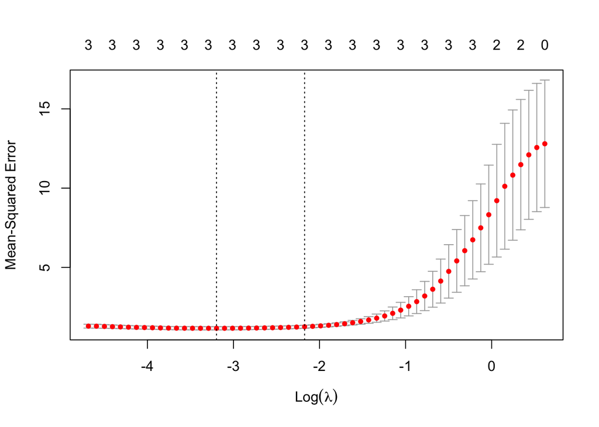

```r
par(mfrow = c(1, 1))
x_matrix <- as.matrix(x_vec)
lasso_fit <- cv.glmnet(x_matrix, Y, alpha = 1, nfolds = 10)
lambda <- lasso_fit$lambda.min
plot(lasso_fit)
```

```r
predict(lasso_fit, s = lambda, type = "coefficients")
```

```
## 11 x 1 sparse Matrix of class "dgCMatrix"
##                    s1
## (Intercept) 4.0990639
## X1          0.6016246
## X2          2.7558447
## X3          0.9232266
## X4          .
## X5          .
## X6          .
## X7          .
## X8          .
## X9          .
## X10         .
```

From the summary result, we can see that Lasso model chooses the best model, which is the same as the previous forward stepwise selection $BIC$ model.

### (f)

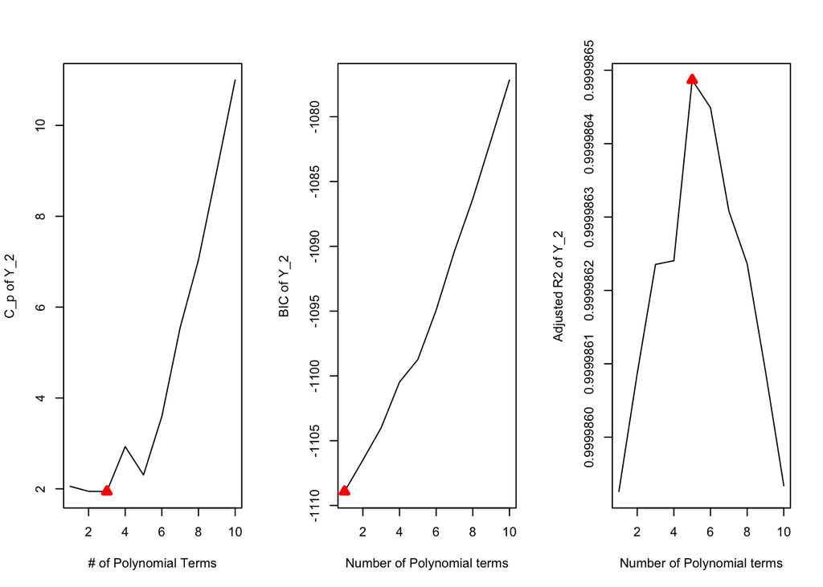

```r
# Define Y_2
Y_2 <- 1 + 2 * x^7 + error

reg_2_all <- regsubsets(Y_2 ~ ., data = data.frame(Y_2, x_vec), nvmax = 10)

par(mfrow = c(1, 3))
reg_2_summary <- summary(reg_2_all)

# Plots

min_cp <- which.min(reg_2_summary$cp)

plot(reg_2_summary$cp, xlab = "# of Polynomial Terms", ylab = "C_p of Y_2", type = "l")
points(min_cp, reg_2_summary$cp[min_cp], col = "red", pch = 2, lwd = 3)

min_bic <- which.min(reg_2_summary$bic)

plot(reg_2_summary$bic, xlab = "Number of Polynomial terms", ylab = "BIC of Y_2", type = "l")

points(min_bic, reg_2_summary$bic[min_bic], col = "red", pch = 2, lwd = 3)

min_adj_R2 <- which.max(reg_2_summary$adjr2)
plot(reg_2_summary$adjr2, xlab = "Number of Polynomial terms",
     ylab = "Adjusted R2 of Y_2", type = "l")
points(min_adj_R2, reg_2_summary$adjr2[min_adj_R2],
       col = "red", pch = 2, lwd = 3)
```

```r
# Coefficients

coef(reg_2_all, min_cp)
```

```
##  (Intercept)           X3           X7           X8
##  0.945199093  0.154553205  1.981871057 -0.005768792
```

```r
coef(reg_2_all, min_bic)
```

```
## (Intercept)          X7
##   0.8931601   2.0004880
```

```r
coef(reg_2_all, min_adj_R2)
```

```
## (Intercept)          X1          X2          X3          X5          X7
##   1.0735139  -0.6837656  -0.2634570   1.1147232  -0.3726221   2.0302519
```

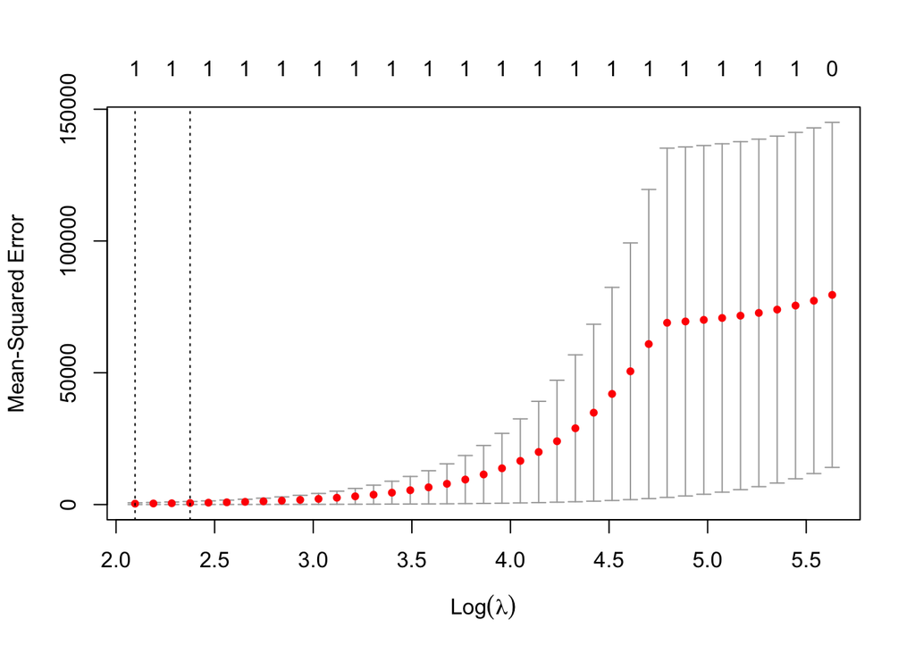

```r
# Lasso regression

par(mfrow = c(1,1))

lasso_fit_2 <- cv.glmnet(x_matrix, Y_2, alpha = 1)
lambda <- lasso_fit_2$lambda.min
plot(lasso_fit_2)
```

```r
predict(lasso_fit_2, s = lambda, type = "coefficients")
```

```
## 11 x 1 sparse Matrix of class "dgCMatrix"
##                     s1
## (Intercept) -0.5765497
## X1           .
## X2           .
## X3           .
## X4           .
## X5           .
## X6           .
## X7           1.9421727
## X8           .
## X9           .
## X10          .
```

The $BIC$ based on the best subset selection model AND the Lasso model identified the correct model. The best subset selection based on adjusted $R^2$ included too many variables.

## Question 7 (6.8-9)

### (a)

```r
# Load required packages
library(ISLR)

set.seed(789)
train_ind <- sample(1:nrow(College), nrow(College) * 0.80)
train_set <- College[train_ind, ]
test_set <- College[-train_ind, ]
```

### (b)

```r
lm_fit <- lm(Apps ~ ., data = train_set)
lm_pred <- predict(lm_fit, test_set)
lm_rmse <- sqrt(mean((test_set$Apps - lm_pred)^2))
lm_rmse
```

```
## [1] 1079.981
```

Therefore, the RMSE on the test set is $1079.981$.

### (c)

```r
# Load required packages
library(glmnet)

xm_train <- model.matrix(Apps ~ ., data = train_set)[, -1]

xm_test <- model.matrix(Apps ~ ., data = test_set)[, -1]

ridge_fit <- cv.glmnet(xm_train, train_set$Apps, alpha = 0) # Set `alpha = 0` to ensure a ridge fit

lambda <- ridge_fit$lambda.min

ridge_pred <- predict(ridge_fit, s = lambda, newx = xm_test)

ridge_rmse <- sqrt(mean((test_set$Apps - ridge_pred)^2))

ridge_rmse
```

```
## [1] 1137.579
```

Thus, the RMSE on the test set for Ridge regression is $1137.579$.

### (d)

```r
lasso_fit_3 <- cv.glmnet(xm_train, train_set$Apps, alpha = 1) # Set `alpha = 1` to ensure a lasso fit

lambda <- lasso_fit_3$lambda.min

lasso_pred <- predict(lasso_fit_3, s = lambda, newx = xm_test)

lasso_rmse <- sqrt(mean((test_set$Apps - lasso_pred)^2))

lasso_rmse
```

```
## [1] 1095.833
```

```r
lasso_coefs <- predict(lasso_fit_3, type = "coefficients", s = lambda)[1:ncol(College), ]

lasso_coefs[lasso_coefs != 0]
```

```
##   (Intercept)    PrivateYes        Accept        Enroll     Top10perc
## -6.539744e+02 -3.277380e+02  1.483141e+00 -2.866530e-01  3.145064e+01
##     Top25perc   P.Undergrad      Outstate    Room.Board      Personal
## -6.994653e-01  2.733250e-02 -7.994689e-02  1.457376e-01  9.167677e-03
##           PhD      Terminal     S.F.Ratio        Expend     Grad.Rate
## -2.309996e+00 -6.207373e+00  5.397371e+00  6.971046e-02  5.669911e+00
```

### (e)

```r
# Load required packages
library(pls)
```

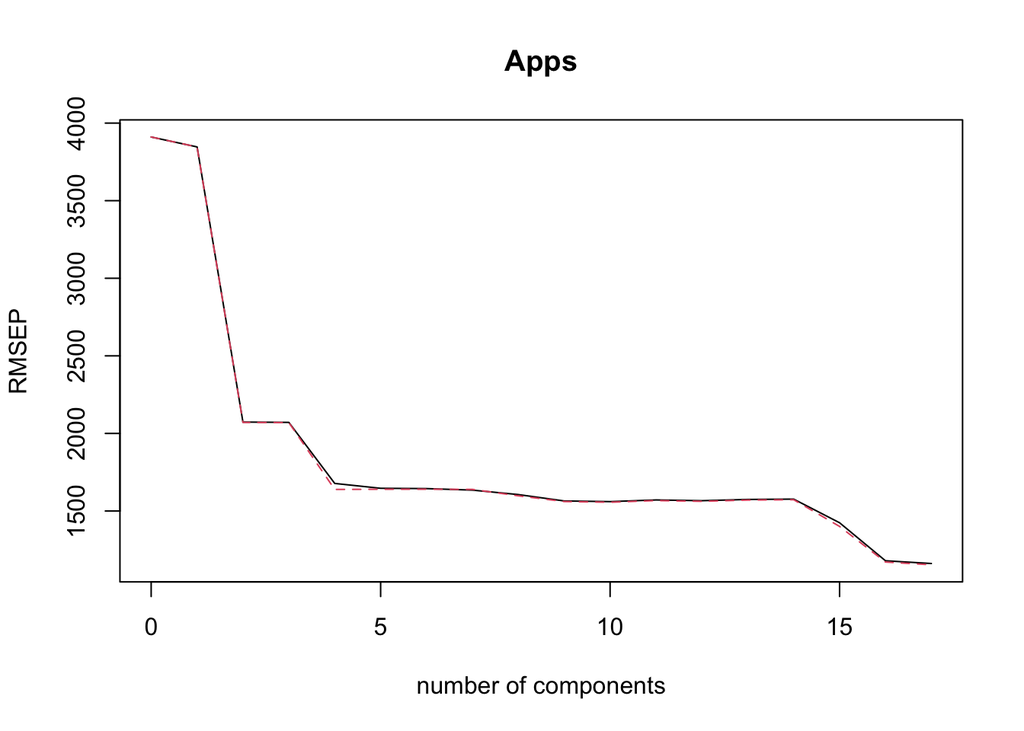

```r
set.seed(644)

pcr_fit <- pcr(Apps ~ ., data = train_set, scale = TRUE, validation = "CV")

validationplot(pcr_fit, val.type = "RMSEP")
```

```r
summary(pcr_fit)
```

```
## Data:    X dimension: 621 17
##  Y dimension: 621 1
## Fit method: svdpc
## Number of components considered: 17
##
## VALIDATION: RMSEP
## Cross-validated using 10 random segments.
##        (Intercept)  1 comps  2 comps  3 comps  4 comps  5 comps  6 comps
## CV            3910     3847     2073     2071     1678     1646     1645
## adjCV         3910     3846     2071     2070     1639     1640     1640
##        7 comps  8 comps  9 comps  10 comps  11 comps  12 comps  13 comps
## CV        1635     1606     1565      1561      1571      1567      1575
## adjCV     1639     1598     1561      1557      1567      1562      1570
##        14 comps  15 comps  16 comps  17 comps
## CV         1577      1424      1179      1162
## adjCV      1573      1401      1171      1154
##
## TRAINING: % variance explained
##       1 comps  2 comps  3 comps  4 comps  5 comps  6 comps  7 comps  8 comps
## X      31.693    57.65    64.45    70.02    75.36    80.20    83.83    87.32
## Apps    3.518    72.57    72.83    83.01    83.45    83.46    83.54    84.53
##       9 comps  10 comps  11 comps  12 comps  13 comps  14 comps  15 comps
## X       90.37     92.75     94.87     96.67     97.80     98.72     99.37
## Apps    85.07     85.29     85.30     85.38     85.38     85.39     91.46
##       16 comps  17 comps
## X        99.87    100.00
## Apps     92.95     93.17
```

```r
error_cv <- RMSEP(pcr_fit)$val[1, , ]

min_cv <- which.min(error_cv) - 1 # min_cv = 17

pcr_pred <- predict(pcr_fit, test_set, ncomp = min_cv)

pcr_rmse <- sqrt(mean((test_set$Apps - pcr_pred)^2))

pcr_rmse
```

```
## [1] 1079.981
```

The value of $M$ selected by CV is $17$; the RMSE on the test set for PCR fit is $1079.981$.

### (f)

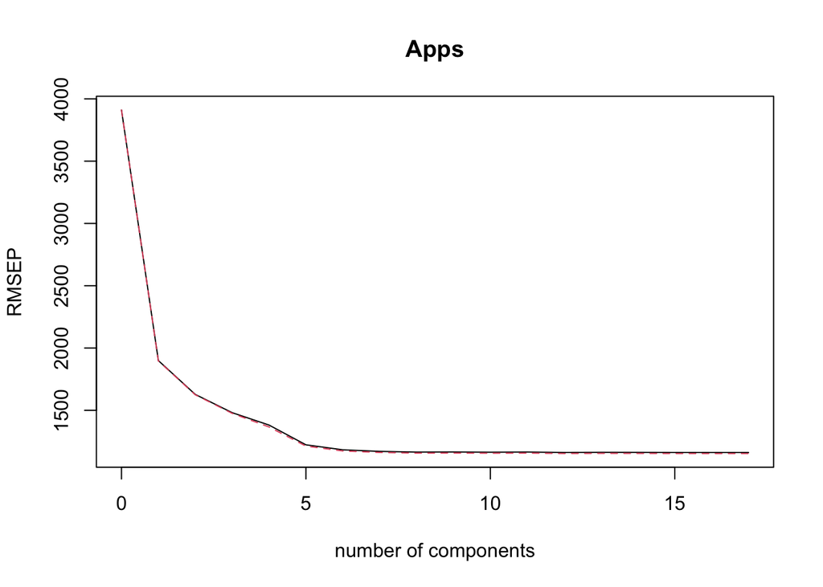

```r
set.seed(644)

pls_fit <- plsr(Apps ~ ., data = train_set, scale = TRUE, validation = "CV")

validationplot(pls_fit, val.type = "RMSEP")
```

```r
summary(pls_fit)
```

```
## Data:    X dimension: 621 17
##  Y dimension: 621 1
## Fit method: kernelpls
## Number of components considered: 17
##
## VALIDATION: RMSEP
## Cross-validated using 10 random segments.
##        (Intercept)  1 comps  2 comps  3 comps  4 comps  5 comps  6 comps
## CV            3910     1899     1628     1481     1382     1223     1183
## adjCV         3910     1896     1625     1476     1366     1213     1174
##        7 comps  8 comps  9 comps  10 comps  11 comps  12 comps  13 comps
## CV        1171     1165     1166      1164      1165      1162      1163
## adjCV     1162     1157     1157      1156      1157      1154      1155
##        14 comps  15 comps  16 comps  17 comps
## CV         1163      1162      1162      1162
## adjCV      1154      1154      1154      1154
##
## TRAINING: % variance explained
##       1 comps  2 comps  3 comps  4 comps  5 comps  6 comps  7 comps  8 comps
## X       26.21    42.34    62.93    65.34    68.91    73.78    76.49    79.68
## Apps    77.40    84.34    87.43    91.11    92.67    93.00    93.05    93.09
##       9 comps  10 comps  11 comps  12 comps  13 comps  14 comps  15 comps
## X       82.42     84.85     87.18     90.03     92.27     95.14     96.81
## Apps    93.12     93.14     93.15     93.17     93.17     93.17     93.17
##       16 comps  17 comps
## X        98.73    100.00
## Apps     93.17     93.17
```

```r
error_cv <- RMSEP(pls_fit)$val[1, , ]

min_cv <- which.min(error_cv) - 1 # min_cv = 16

pls_pred <- predict(pls_fit, test_set, ncomp = min_cv)

pls_rmse <- sqrt(mean((test_set$Apps - pls_pred)^2))

pls_rmse
```

```
## [1] 1079.969
```

The value of $M$ selected by CV is $16$; the RMSE on the test set is $1079.969$.

### (g)

```r
error_all <- c(lm_rmse, ridge_rmse, lasso_rmse, pcr_rmse, pls_rmse)

names(error_all) <- c("lm", "ridge", "lasso", "pcr", "pls")

error_all
```

```
##       lm    ridge    lasso      pcr      pls
## 1079.981 1137.579 1095.833 1079.981 1079.969
```

It seems that Ridge regression performed a little bit off compared to the rest of the models. PCR & PLS model seem to perform equally well compared to the simple linear model.